# Langage Julia

Cours ENPC - Pratique du calcul scientifique

[figure not shown]

- Langage de programmation créé en 2009 au MIT
- Par Jeff Bezanson, Stefan Karpinski, Viral B. Shah, Alan Edelman
- Version 1.8.5 depuis le 08/01/2023
- Documentation générale de `Julia` : https://docs.julialang.org/en/v1/

## Installation de `Julia` → deux options

1. Versions individuelles depuis https://julialang.org/

[interactive chart not shown]

2. Gestionnaire de versions `juliaup` (future méthode officielle)
- installer `juliaup` depuis https://github.com/JuliaLang/juliaup
- ajouter des versions, par exemple la dernière

  ```bash
  PS [path] juliaup add release
  ```

## Editeur de développement (IDE)

- Option préconisée : `VSCode` → https://code.visualstudio.com/
- Installer `Jupyter` → https://jupyter.org/install
- Installer la bibliothèque `IJulia` → https://github.com/JuliaLang/IJulia.jl
- Installer les extensions [Julia](https://marketplace.visualstudio.com/items?itemName=julialang.language-julia) et [Jupyter](https://marketplace.visualstudio.com/items?itemName=ms-toolsai.jupyter) pour `VSCode`

[interactive chart not shown]

- Voir vidéos de D. Anthoff sur l’utilisation de `VSCode` pour `Julia`, p. ex. [lien 1](https://youtu.be/IdhnP00Y1Ks) ou [lien 2](https://youtu.be/Okn_HKihWn8)

## Le REPL et quelques commandes importantes à connaître

- REPL = read–eval–print loop → console de Julia
- Le REPL est accessible
  - de manière autonome en tant qu’exécutable ou en tapant `julia` dans une console (si `PATH` à jour)
  - intégré dans `VSCode` en tapant `Maj+Ctrl+P` puis en cherchant `Julia: Start REPL`

    Dans `VSCode`, on peut taper ses lignes de code dans un fichier `monfichier.jl` et les lancer une par une dans la console intégrée par `Maj+Entrée`.
- Depuis le REPL, taper
  - `]` donne accès au gestionnaire de bibliothèques
  - `;` donne accès au *shell mode*
  - `?` donne accès à l’aide en ligne
  - `⟵` retourne au mode normal
  - `Tab` pour la complétion automatique
  - les flèches haut et bas pour naviguer dans l’historique (éventuellement filtré par le début de ligne tapé)

[figure not shown]

# Pourquoi `Julia` ?

- `Julia` est facile à apprendre, à lire et à maintenir
- `Julia` est rapide
- `Julia` est efficace
- `Julia` est bien adapté au calcul scientifique

## `Julia` est facile à apprendre, à lire et à maintenir

- Typage dynamique

```julia
x = 1 ; y = π ; z = 1//2 ; t = x + y + z
```

```
4.641592653589793
```

```julia
for v ∈ (x,y,z,t) println("$v is a $(typeof(v))") end
```

```
1 is a Int64
π is a Irrational{:π}
1//2 is a Rational{Int64}
4.641592653589793 is a Float64
```

- Mais possibilité de typage statique

```julia
f(x) = 2x
f(x::Float64) = 3x
@show f(1)
@show f(1.) ;
```

```
f(1) = 2
f(1.0) = 3.0
```

- Définition simplifiée de fonctions courtes (équivalent du `lambda` de python)
- Bibliothèque de base contient les tableaux et leurs opérations courantes (`+`, `-`, `*`, `\`) puis `LinearAlgebra` pour `det`, `eigen`…
- Compréhension de tableau (`for` dans le tableau)

```julia
A = [63/(i+2j) for i ∈ 1:3, j ∈ 1:3]
```

```
3×3 Matrix{Float64}:
 21.0   12.6  9.0
 15.75  10.5  7.875
 12.6    9.0  7.0
```

```julia
x = [1.2, 3.4, 5.6]
b = A*x
A\b
```

```
3-element Vector{Float64}:
 1.2000000000000342
 3.3999999999998263
 5.600000000000162
```

```julia
@show A\b == x
@show A\b ≈ x ;
```

```
A \ b == x = false
A \ b ≈ x = true
```

- Numérotation commence à 1 et remplissage par colonne
- Caractères unicode

```julia
𝒢(x,μ=0.,σ=1.) = 1/σ√(2π) * exp(-(x-μ)^2/2σ^2)
```

```
𝒢 (generic function with 3 methods)
```

```julia
@show Σaᵢⱼ² = sum(A.^2)
@show √Σaᵢⱼ² ;
```

```
Σaᵢⱼ² = sum(A .^ 2) = 1389.848125
√Σaᵢⱼ² = 37.28066690658846
```

- Nouveaux opérateurs binaires

```julia
⊕(α,β) = α + β
5 ⊕ 7
```

```
12
```

```julia
⊕(α::Array{T,2}, β::Array{T,2}) where {T} = α + β'
```

```
⊕ (generic function with 2 methods)
```

```julia
display(A + A)
display(A ⊕ A)
```

```
3×3 Matrix{Float64}:
 42.0  25.2  18.0
 31.5  21.0  15.75
 25.2  18.0  14.0
```

```
3×3 Matrix{Float64}:
 42.0   28.35   21.6
 28.35  21.0    16.875
 21.6   16.875  14.0
```

## `Julia` est rapide

- Compilation à la volée (*Just-in-time compilation*)
- Parangonnage (cf. https://julialang.org/benchmarks)

[figure not shown]

⚠ Ces résultats ne tiennent pas compte du temps de compilation.

The vertical axis shows each benchmark time normalized against the C implementation. The benchmark data shown above were computed with Julia v1.0.0, SciLua v1.0.0-b12, Rust 1.27.0, Go 1.9, Java 1.8.0_17, Javascript V8 6.2.414.54, Matlab R2018a, Anaconda Python 3.6.3, R 3.5.0, and Octave 4.2.2. C and Fortran are compiled with gcc 7.3.1, taking the best timing from all optimization levels (-O0 through -O3). C, Fortran, Go, Julia, Lua, Python, and Octave use OpenBLAS v0.2.20 for matrix operations; Mathematica uses Intel MKL. The Python implementations of matrix_statistics and matrix_multiply use NumPy v1.14.0 and OpenBLAS v0.2.20 functions; the rest are pure Python implementations. Raw benchmark numbers in CSV format are available under https://github.com/JuliaLang/Microbenchmarks.

These micro-benchmark results were obtained on a single core (serial execution) on an Intel Core i7-3960X 3.30GHz CPU with 64GB of 1600MHz DDR3 RAM, running openSUSE LEAP 15.0 Linux.

## `Julia` est efficace

Un atout majeur est le *multiple dispatch*

Exemple tiré de la conférence [*The Unreasonable Effectiveness of Multiple Dispatch*](https://www.youtube.com/watch?v=kc9HwsxE1OY) de Stefan Karpinski

```julia
abstract type Animal end
struct Chien <: Animal; nom::String end
struct Chat <: Animal; nom::String end

function rencontre(a::Animal,b::Animal)
    verb = agit(a,b)
    println("$(a.nom) rencontre $(b.nom) et $verb")
end

agit(a::Chien,b::Chien) = "le renifle" ; agit(a::Chien,b::Chat) = "le chasse"
agit(a::Chat,b::Chien) = "s'enfuit" ; agit(a::Chat,b::Chat) = "miaule"

medor = Chien("Médor") ; 🐶 = Chien("🐶")
felix = Chat("Félix") ; 🐱 = Chat("🐱")

rencontre(medor,🐶)
rencontre(🐶,felix)
rencontre(felix,🐶)
rencontre(🐱,felix)
```

```
Médor rencontre 🐶 et le renifle
🐶 rencontre Félix et le chasse
Félix rencontre 🐶 et s'enfuit
🐱 rencontre Félix et miaule
```

Exemple adapté du [blog de Mosè Giordano](https://www.juliabloggers.com/rock-paper-scissors-game-in-less-than-10-lines-of-code/)

```julia
abstract type HandShape end
struct Rock     <: HandShape end
struct Paper    <: HandShape end
struct Scissors <: HandShape end
play(::Type{Paper}, ::Type{Rock}) = println("Paper VS Rock ⇒ Paper wins")
play(::Type{Scissors}, ::Type{Paper}) = println("Scissors VS Paper ⇒ Scissors wins")
play(::Type{Rock}, ::Type{Scissors}) = println("Rock VS Scissors ⇒ Rock wins")
play(::Type{T}, ::Type{T}) where {T<: HandShape} = println("Tie between $(T), try again")
play(a::Type{<:HandShape}, b::Type{<:HandShape}) = play(b, a) # Commutativity
play(Paper, Rock)
play(Scissors, Scissors)
play(Paper, Scissors)
```

```
Paper VS Rock ⇒ Paper wins
Tie between Scissors, try again
Scissors VS Paper ⇒ Scissors wins
```

Il est aisé d’ajouter de nouveaux types *a posteriori*

```julia
struct Well <: HandShape end
play(::Type{Well}, ::Type{Rock})     = "Well VS Rock ⇒ Well wins"
play(::Type{Well}, ::Type{Scissors}) = "Well VS Scissors ⇒ Well wins"
play(::Type{Paper}, ::Type{Well})    = "Paper VS Well ⇒ Paper wins"
play(Scissors, Well)
```

```
"Well VS Scissors ⇒ Well wins"
```

## `Julia` est bien adapté au calcul scientifique

- Différentiation automatique

```julia
using Zygote
f(x) = log(x)
f'(2), f''(2)
```

```
(0.5, -0.25)
```

- Calculs dimensionnels

```julia
using Unitful
m = u"m" ; cm = u"cm" ;
@show 1.0m + 1.0cm
println()
@show 1.0u"MPa" + 2.0u"bar" + 3.0u"daN/cm^2"
println()
@show uconvert(u"MPa",1u"bar")
;
```

```
1.0m + 1.0cm = 1.01 m

1.0 * u"MPa" + 2.0 * u"bar" + 3.0 * u"daN/cm^2" = 1.5e6 kg m^-1 s^-2

uconvert(u"MPa", 1 * u"bar") = 1//10 MPa
```

- Equations différentielles

```julia
using ModelingToolkit, Symbolics, DifferentialEquations, Plots
@parameters t
∂_∂(x) = y -> expand_derivatives(Differential(x)(y))
d_dt = ∂_∂(t)
q = @variables θ(t) ϕ(t) ψ(t)
θ̇, ϕ̇, ψ̇ = q̇ = d_dt.(q)
q̈ = d_dt.(q̇)
@parameters g R M m₁ m₂ ℓ₁ ℓ₂ L ;
```

… éq. d’Euler-Lagrange $\frac{{\mathrm{d}}}{{\mathrm{d}}t}\left(\frac{∂ℒ}{∂\dot{q_i}}\right) -\frac{∂ℒ}{∂q_i}=0$

```julia
K = Jᴵ * θ̇^2 / 2 + m₁ * (ẋ₁^2 + ẏ₁^2) / 2 + m₂ * (ẋ₂^2 + ẏ₂^2) / 2
V = -M * g * yᴳ * cos(θ) + m₁ * g * y₁ + m₂ * g * y₂
ℒ = K - V
EL = [d_dt(∂_∂(v̇)(ℒ)) - ∂_∂(v)(ℒ) for (v̇, v) ∈ zip(q̇, q)] ;
```

…

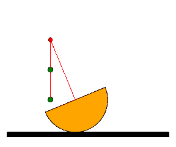

- Calcul tensoriel

```julia
using SymPy, LinearAlgebra, TensND
Spherical = coorsys_spherical()
θ, ϕ, r = getcoords(Spherical)
𝐞ᶿ, 𝐞ᵠ, 𝐞ʳ = unitvec(Spherical)
@set_coorsys Spherical
𝕀, 𝕁, 𝕂 = ISO() ; 𝟏 = tensId2()
k, μ = symbols("k μ", positive = true)
λ = k -2μ/3
u = SymFunction("u", real = true)
𝛆 = SYMGRAD(u(r) * 𝐞ʳ)
𝛆 |> intrinsic
```

```
(u(r)/r)𝐞ᶿ⊗𝐞ᶿ + (u(r)/r)𝐞ᵠ⊗𝐞ᵠ + (Derivative(u(r), r))𝐞ʳ⊗𝐞ʳ
```

```julia
𝛔 = λ * tr(𝛆) * 𝟏 + 2μ * 𝛆
eq = DIV(𝛔) ⋅ 𝐞ʳ
sol = dsolve(eq, u(r))
```

$u{\left(r \right)} = \frac{C_{1}}{r^{2}} + C_{2} r$

```julia
T̂ = tfactor(tsimplify(tsubs(𝐞ʳ ⋅ 𝛔 ⋅ 𝐞ʳ, u(r) => sol.rhs())))
```

$\frac{- 4 C_{1} μ + 3 C_{2} k r^{3}}{r^{3}}$

## Références pour auto-formation

- La documentation officielle → https://docs.julialang.org/en/v1/
- *Learn X in Y minutes* → https://learnxinyminutes.com/docs/julia
- *Intro to Julia tutorial (version 1.0) by Jane Herriman* → https://youtu.be/8h8rQyEpiZA
- *The Unreasonable Effectiveness of Multiple Dispatch* → https://www.youtube.com/watch?v=kc9HwsxE1OY